# Internet Access, in relationship to GDP and College Enrollment

Friday, April 24, 2015

### Purpose of Study

The internet is often a tool of democritization and progress, which can foster a society which is more productive, healthy, and free. However, the effect is diffictult to measure, because a society which is already productive and democratic is more likely to grant access to the internet. This study intends to show what relationship exists between per capita internet use and indicators of social and civic progress, with a focus on controlling as much as possible for everything else which would influence that progress. It’s starting with the assumption that there is a very strong connection, then essentially doing everything possible to remove it throught controls, and seeing what remains.

### Variables

So far, only GDP per Capita, Web Access Per capita, and College Enrollment(Gross % of college-age people) have been investigated. These are pulled from the WDI indicators ans labeled `gdp.cap`,`web.cap`, and `ter.cap` respectively.

### Creation of Dataframe

The code used here is a bit of a bruteforce approach…

```r
DF<-cbind(rename(WDI(indicator="IT.NET.USER.P2"), web.cap=IT.NET.USER.P2),
          rename(WDI(indicator="SE.SEC.ENRR"), sec.cap= SE.SEC.ENRR),
          rename(WDI(indicator="SE.TER.ENRR"), ter.cap= SE.TER.ENRR),
          rename(WDI(indicator="SE.XPD.TOTL.GB.ZS"), edubux= SE.XPD.TOTL.GB.ZS),
          rename(WDI(indicator="NY.GDP.PCAP.CD"), gdp.cap= NY.GDP.PCAP.CD),
          rename(WDI(indicator="SH.HIV.1524.FE.ZS"), fHIV= SH.HIV.1524.FE.ZS),
          rename(WDI(indicator="SH.HIV.1524.MA.ZS"), mHIV= SH.HIV.1524.MA.ZS),
          rename(WDI(indicator="SP.MTR.1519.ZS"),teenmom= SP.MTR.1519.ZS),
          rename(WDI(indicator="SH.DYN.AIDS.ZS"), tHIV=SH.DYN.AIDS.ZS),
          rename(WDI(indicator="SP.DYN.CONU.ZS"), contrac=SP.DYN.CONU.ZS),
          rename(WDI(indicator="EG.ELC.ACCS.ZS"),elec.cap=EG.ELC.ACCS.ZS),
          rename(WDI(indicator="SE.ENR.TERT.FM.ZS"),ter.gdr=SE.ENR.TERT.FM.ZS),
          rename(WDI(indicator="SL.EMP.INSV.FE.ZS"),wrk.fem=SL.EMP.INSV.FE.ZS))
attach(DF)
DF2<-as.data.frame(cbind(country,year,web.cap,elec.cap,gdp.cap,sec.cap,ter.cap,edubux,fHIV,mHIV,tHIV,teenmom,contrac, ter.gdr, wrk.fem))
detach(DF)
DF<-DF2
rm(DF2)
```

Some of those not mentioned before are HIV rates among men and women, money spent on education, and women in the workforce. At this point there is a DataFrame with the variables of interest. Unfortunately they are all coded as factors, so a similar bruteforce method is used to get them all coded numerically.

```r
DF$web.cap<-as.numeric(as.character(DF$web.cap))
DF$sec.cap<-as.numeric(as.character(DF$sec.cap))
DF$ter.cap<-as.numeric(as.character(DF$ter.cap))
DF$edubux<-as.numeric(as.character(DF$edubux))
DF$gdp.cap<-as.numeric(as.character(DF$gdp.cap))
DF$year<-as.numeric(as.character(DF$year))
DF$fHIV<-as.numeric(as.character(DF$fHIV))
DF$mHIV<-as.numeric(as.character(DF$mHIV))
DF$teenmom<-as.numeric(as.character(DF$teenmom))
DF$tHIV<-as.numeric(as.character(DF$tHIV))
DF$contrac<-as.numeric(as.character(DF$contrac))
DF$elec.cap<-as.numeric(as.character(DF$elec.cap))
DF$ter.gdr<-as.numeric(as.character(DF$ter.gdr))
DF$wrk.fem<-as.numeric(as.character(DF$wrk.fem))
```

At this point we have variables of interest for all countries, as well as averages for all regions, for all years from 2005 to 2011. Because including regional averages would in a sense double-count the data from those countries, it’s good to cut down the data to just country statistics. The data is helpfully indexed in a way where the regions are all up at the beginning rather than mixed alphabetically with the rest of the data, so this is actually just a simple command.

```r
DF.c<-DF[239:1736,]
```

At this point the filter command from dplyr to investigate all sorts of data.

### Univariate Analysis

(There are no categorical variables of interest. The numeric variables could be cut into intervals to force a categotical study, but this results in information loss. In lieu of that, here are three numeric graphs/analyses.)

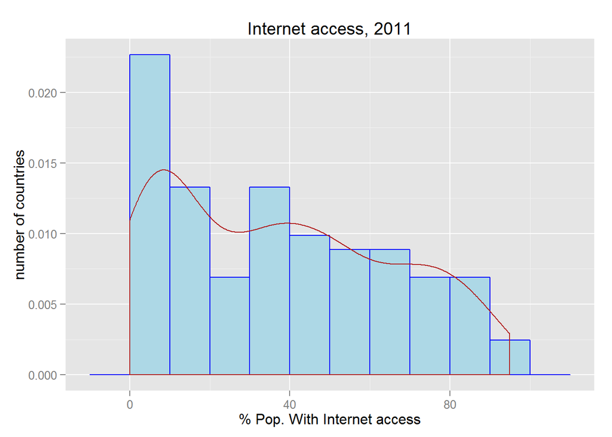

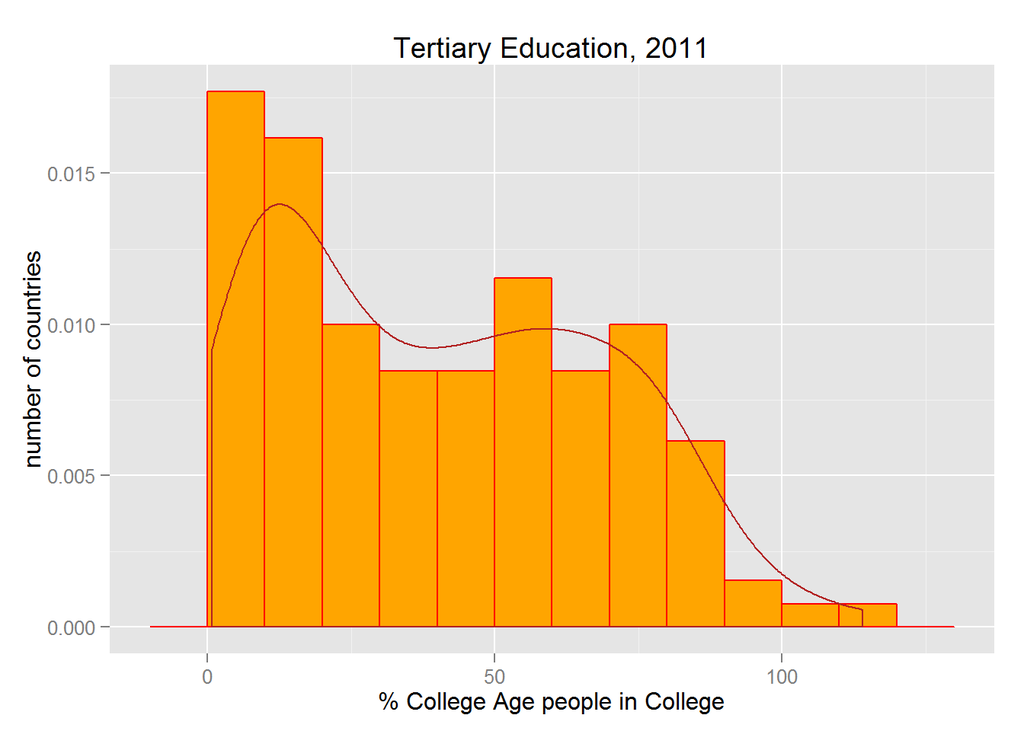

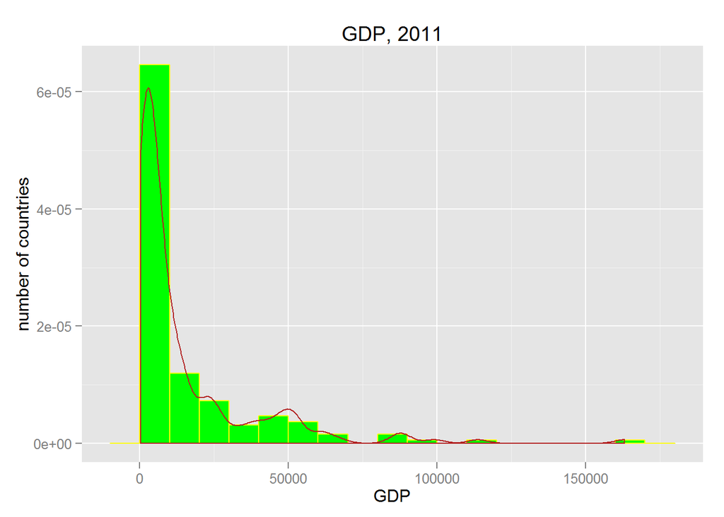

All are right-skewed, GDP heavily so. This may give result in problems with assumptions for inference down the line.

### Bivariate Analysis

One interesting measure to look at is how many kids attend college, with respect to their country’s level of internet access.

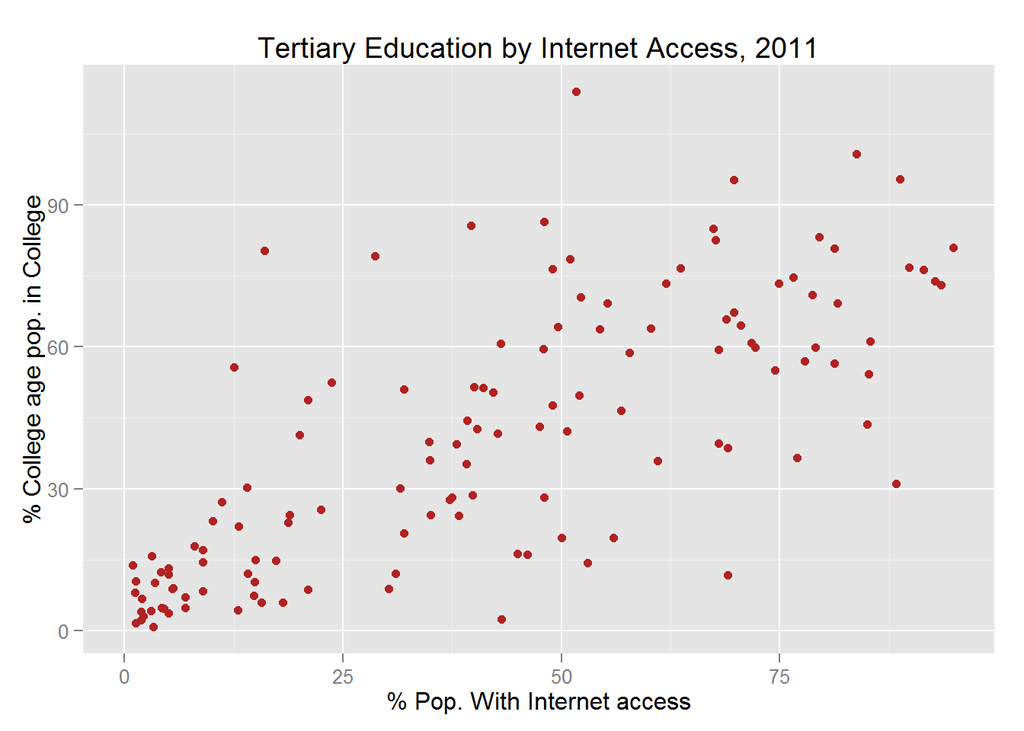

### Multivariate Analysis

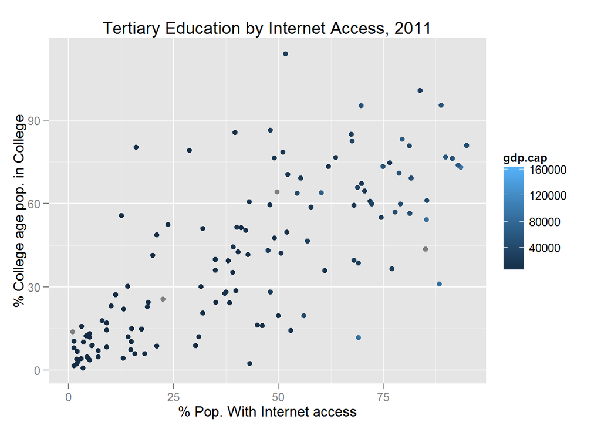

We do see that the color, indicating GDP per capita, gets brighter as both internet access and college attendance increase. This can be shown with scatterplots as well.

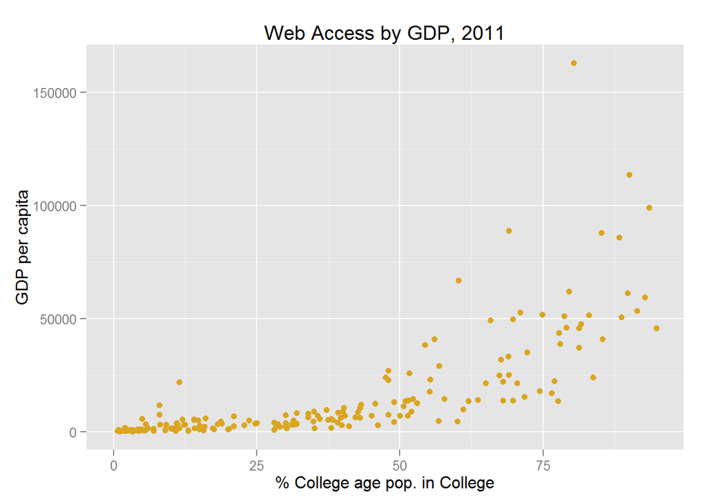

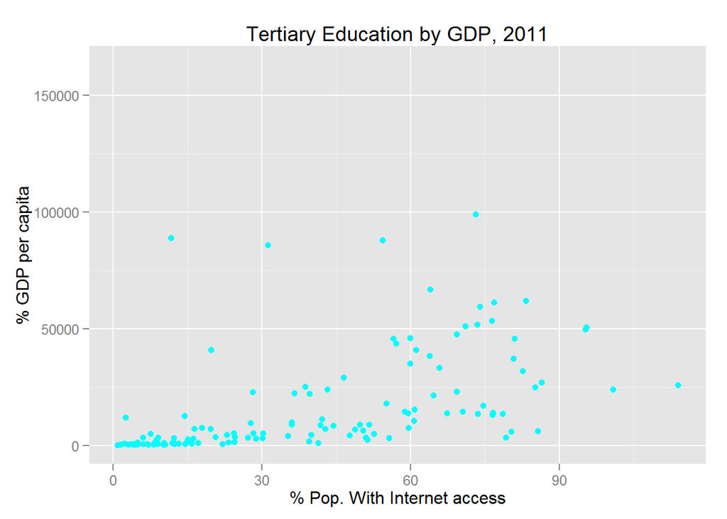

Clearly these relationships are a bit stronger.

I can divide the web data into quartiles and test if there are significant differences between them with aov.

```r
quartile<- (as.integer(cut(DF.c.2011$web.cap, quantile(DF.c.2011$web.cap, probs=0:4/4, na.rm=T), include.lowest=TRUE)))
DF.c.2011.q<-cbind(DF.c.2011,quartile)
summary(aov(gdp.cap~quartile, data=DF.c.2011.q))
```

```
##              Df    Sum Sq   Mean Sq F value Pr(>F)
## quartile      1 4.368e+10 4.368e+10   140.4 <2e-16 ***
## Residuals   187 5.817e+10 3.111e+08
## ---
## Signif. codes:  0 '***' 0.001 '**' 0.01 '*' 0.05 '.' 0.1 ' ' 1
## 25 observations deleted due to missingness
```

With an off-the-charts low p-value, there is clear evidence that there are differences in GDP between the quartiles.

### Chi-Square

We can also run a chi square test, dividing one of the variables into 2 levels. Say, “low internet use” and “high internet use”

```
##         quartile.gdp
## half.web  1  2  3  4
##        1 48 36 13  1
##        2  0 10 34 47
```

```
##         quartile.gdp
## half.web          1          2          3          4
##        1 1.00000000 0.78260870 0.27659574 0.02083333
##        2 0.00000000 0.21739130 0.72340426 0.97916667
```

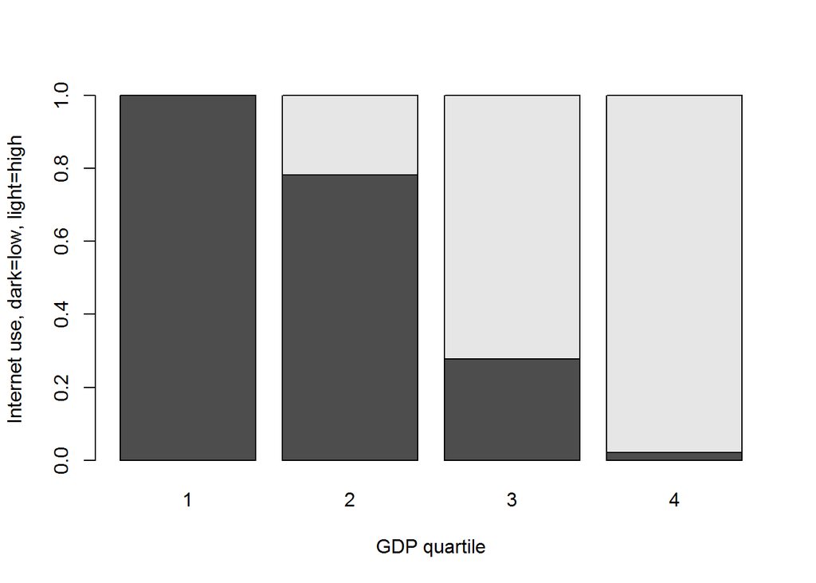

```
##
##  Pearson's Chi-squared test
##
## data:  T1
## X-squared = 116.0619, df = 3, p-value < 2.2e-16
```

```r
Ta <- xtabs(~half.web + quartile.gdp, data = DF.c.2011[DF.c.2011$quartile.gdp==1|DF.c.2011$quartile.gdp==2])
Tb <- xtabs(~half.web + quartile.gdp, data = DF.c.2011[DF.c.2011$quartile.gdp==1|DF.c.2011$quartile.gdp==3])
Tc <- xtabs(~half.web + quartile.gdp, data = DF.c.2011[DF.c.2011$quartile.gdp==1|DF.c.2011$quartile.gdp==4])
Td <- xtabs(~half.web + quartile.gdp, data = DF.c.2011[DF.c.2011$quartile.gdp==2|DF.c.2011$quartile.gdp==3])
Te <- xtabs(~half.web + quartile.gdp, data = DF.c.2011[DF.c.2011$quartile.gdp==2|DF.c.2011$quartile.gdp==4])
Tf <- xtabs(~half.web + quartile.gdp, data = DF.c.2011[DF.c.2011$quartile.gdp==3|DF.c.2011$quartile.gdp==4])

chisq.test(Ta)
```

```
##
##  Pearson's Chi-squared test
##
## data:  Ta
## X-squared = 116.0619, df = 3, p-value < 2.2e-16
```

```r
chisq.test(Tb)
```

```
##
##  Pearson's Chi-squared test
##
## data:  Tb
## X-squared = 116.0619, df = 3, p-value < 2.2e-16
```

```r
chisq.test(Tc)
```

```
##
##  Pearson's Chi-squared test
##
## data:  Tc
## X-squared = 116.0619, df = 3, p-value < 2.2e-16
```

```r
chisq.test(Td)
```

```
##
##  Pearson's Chi-squared test
##
## data:  Td
## X-squared = 116.0619, df = 3, p-value < 2.2e-16
```

```r
chisq.test(Te)
```

```
##
##  Pearson's Chi-squared test
##
## data:  Te
## X-squared = 116.0619, df = 3, p-value < 2.2e-16
```

```r
chisq.test(Tf)
```

```
##
##  Pearson's Chi-squared test
##
## data:  Tf
## X-squared = 116.0619, df = 3, p-value < 2.2e-16
```

### Correlation

Let’s look at the linear relationship between GDP and pursuit of college education.

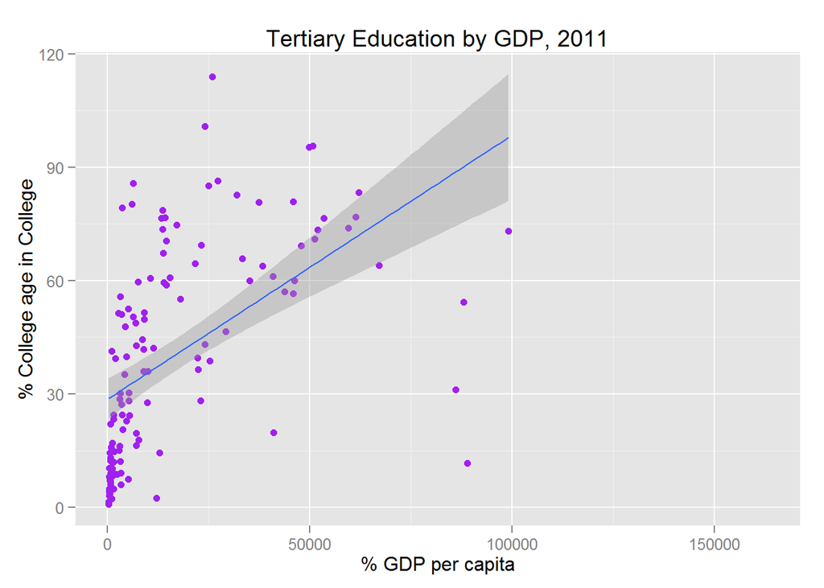

Though there is a clear positive trend, this line doesn’t seem to fit the data all too well. A transformation may be needed down the line, but for now, let’s look at the correlation coefficient.

```r
cor(y=DF.c.2011$ter.cap, x=DF.c.2011$gdp.cap, use="complete")
```

```
## [1] 0.5317421
```

This confirms the intuitive judgment. The association is positive, but weak.

### Moderation

The possible moderator of interest is web access. This is sort of a rephrasing of what the purpose of study isfor this variable: Does accass to internet change the existing relationship between GDP and pursuit of education?

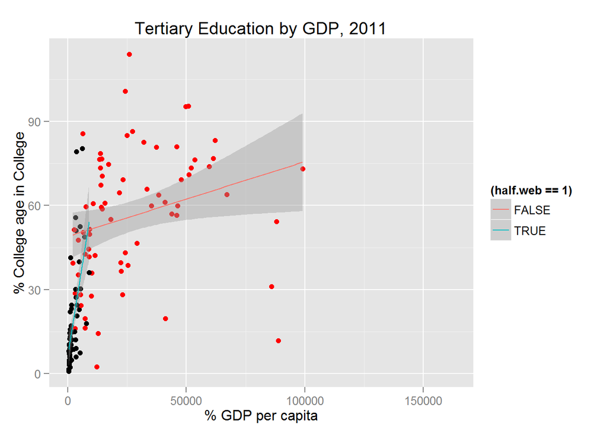

It appears it does! We can test this by creating a model with an interaction term between GDP and internet access, and assuming the null hypothesis that such a term has a coefficient of zero. A low p value would cause us to reject this null and conclude that an interaction exists.

```r
summary(lm(ter.cap~ gdp.cap + half.web + gdp.cap*(half.web-1), data=DF.c.2011)) #The "-1" turns half.web into a dummy with levels 0 and 1
```

```
##
## Call:
## lm(formula = ter.cap ~ gdp.cap + half.web + gdp.cap * (half.web -
##     1), data = DF.c.2011)
##
## Residuals:
##     Min      1Q  Median      3Q     Max
## -66.428 -15.423  -4.675  10.826  60.714
##
## Coefficients:
##                    Estimate Std. Error t value Pr(>|t|)
## gdp.cap           0.0030521  0.0020054   1.522    0.131
## half.web         21.5051685  1.7630472  12.198   <2e-16 ***
## gdp.cap:half.web -0.0013285  0.0009906  -1.341    0.182
## ---
## Signif. codes:  0 '***' 0.001 '**' 0.01 '*' 0.05 '.' 0.1 ' ' 1
##
## Residual standard error: 21.02 on 123 degrees of freedom
##   (88 observations deleted due to missingness)
## Multiple R-squared:  0.822,  Adjusted R-squared:  0.8176
## F-statistic: 189.3 on 3 and 123 DF,  p-value: < 2.2e-16
```

The intuitive answer in this case is not quite true. The p-value of the test is found under “Pr(>|t|)”. If we are testing at alpha=.05, the interaction term is not significant.

### Logistic Regression

If the response of interest whether one’s internet access was below or above the median, one could use per-capita GDP and the per-capita college attendance to predict this using Logistic Regression. This regression model is as follows: $\hat{P}(Upper Half)= \frac{e^{\hat\beta_{0}+\hat\beta_{1}(GDP)+\hat\beta_{2}(College)}} {1+e^{\hat\beta_{0}+\hat\beta_{1}(GDP)+\hat\beta_{2}(College)}}$ The $\hat\beta$ terms are predicted coefficients of the variables. The interpretation is not very intuitive, but they are the per-unit increase in the log-odds of a country being in the top half in web access.

For each variable, a test is performed on the null hypothesis that it has no linear relationship to the log-odds, so $H_{0}: \beta=0$ $H_{a}: \beta \neq 0$

Using the glm command in R:

```r
logit<-glm(data=DF.c.2011, (half.web-1)~ gdp.cap+ter.cap, family=binomial(link="logit"))
summary(logit)
```

```
##
## Call:
## glm(formula = (half.web - 1) ~ gdp.cap + ter.cap, family = binomial(link = "logit"),
##     data = DF.c.2011)
##
## Deviance Residuals:
##      Min        1Q    Median        3Q       Max
## -2.01651  -0.29672   0.00000   0.07579   2.10012
##
## Coefficients:
##               Estimate Std. Error z value Pr(>|z|)
## (Intercept) -4.0039100  0.8274703  -4.839 1.31e-06 ***
## gdp.cap      0.0005772  0.0001417   4.072 4.65e-05 ***
## ter.cap      0.0197187  0.0177975   1.108    0.268
## ---
## Signif. codes:  0 '***' 0.001 '**' 0.01 '*' 0.05 '.' 0.1 ' ' 1
##
## (Dispersion parameter for binomial family taken to be 1)
##
##     Null deviance: 172.093  on 125  degrees of freedom
## Residual deviance:  53.823  on 123  degrees of freedom
##   (88 observations deleted due to missingness)
## AIC: 59.823
##
## Number of Fisher Scoring iterations: 9
```

The resulting p-values would suggest that GDP is certainly related to web access, but we can’t determine that per-capita college enrollment is.